# Análisis de la adopción de tecnologías avanzadas 4.0 en la industria de la construcción

Ing. David Alexander Calderón Arregui

Universidad Nacional de Cuyo  
dacalderon07@gmail.com

12/12/2025

**Disponible en:**  
[RPubs – Análisis Construcción 4.0](https://rpubs.com/dacalderon07/analisis-construccion-40)

# 1 Introducción

La industria de la construcción atraviesa en los últimos años un proceso profundo de transformación impulsado por la digitalización y la integración de tecnologías emergentes. Este cambio, ampliamente conocido como Construcción 4.0, se caracteriza por la adopción de herramientas digitales avanzadas que permiten mejorar la eficiencia operativa, optimizar la toma de decisiones y elevar los estándares de calidad y sostenibilidad en los proyectos de ingeniería y construcción (Oesterreich & Teuteberg, 2016). Tecnologías como Building Information Modeling (BIM), Internet de las Cosas (IoT), Inteligencia Artificial (IA), computación en la nube, automatización y gemelos digitales se han posicionado como pilares estratégicos para la modernización del sector; sin embargo, su integración efectiva depende de factores organizacionales, técnicos y humanos que varían significativamente entre empresas (Sacks et al., 2020).

A pesar del notable avance digital observado en industrias como la manufactura y la logística, la construcción continúa siendo uno de los sectores con menor nivel de adopción tecnológica, debido a la fragmentación de sus procesos, la resistencia al cambio, los elevados costos iniciales y la falta de estandarización en el uso de herramientas digitales (Barbosa et al., 2017). En el contexto latinoamericano, estos desafíos se intensifican, ya que muchas empresas enfrentan limitaciones estructurales relacionadas con la inversión en innovación, la disponibilidad de capacidades digitales y la existencia de marcos normativos que promuevan la transformación digital (Betancourt et al., 2021).

En Ecuador, la incorporación de Tecnologías 4.0 dentro del sector de la construcción se encuentra en una etapa de desarrollo desigual. Mientras algunas empresas han iniciado procesos de modernización apoyados en herramientas como BIM, la computación en la nube o la sensorización de obra, otras mantienen prácticas convencionales que restringen la eficiencia y la trazabilidad de los proyectos. Este escenario evidencia la necesidad de contar con diagnósticos sistemáticos que permitan comprender el nivel actual de adopción tecnológica, identificar brechas internas, reconocer barreras y conocer los factores que influyen en la madurez digital de las organizaciones del sector.

En este marco, el presente estudio se alinea con el proyecto de investigación es evaluar la adopción de Tecnologías 4.0 en SEDEMI, una empresa ecuatoriana dedicada a la ingeniería y construcción de soluciones industriales. El objetivo del artículo es analizar el nivel de implementación de tecnologías emergentes en la organización, así como explorar su distribución, variabilidad y contribución al nivel de madurez tecnológica. Para ello, se emplea un enfoque de analítica de datos basado en tres instrumentos de evaluación: diagnóstico de uso tecnológico, madurez organizacional y barreras y fuerzas para la adopción. El análisis se desarrolla con apoyo de R y técnicas estadísticas descriptivas, correlacionales y de construcción de indicadores compuestos.

Los resultados presentados permiten no solo caracterizar el estado actual de la digitalización en SEDEMI, sino también aportar evidencia relevante para la toma de decisiones estratégicas orientadas a fortalecer la competitividad y la transición hacia un modelo de gestión basado en la Construcción 4.0. Asimismo, contribuyen al cuerpo de literatura regional sobre transformación digital en la industria de la construcción, un campo que requiere investigaciones aplicadas que articulen teoría, datos empíricos y necesidades reales de las empresas del sector.

# 2 Metodología

El estudio se desarrolló mediante un enfoque cuantitativo basado en analítica de datos, cuyo propósito fue caracterizar el nivel de adopción de Tecnologías 4.0 en SEDEMI y evaluar su relación con la madurez tecnológica organizacional. La metodología se estructuró en tres fases: recolección de datos mediante encuestas especializadas, depuración y estructuración de la información en R, y aplicación de técnicas estadísticas descriptivas y exploratorias para interpretar los resultados. Este enfoque se alinea con metodologías previas de diagnóstico digital en el sector construcción, que recomiendan el uso de instrumentos estandarizados y análisis multivariable para evaluar el grado de transformación organizacional (Carrillo & Patel, 2021; Delgado & Aranda-Mena, 2023).

La recolección de datos se llevó a cabo mediante tres encuestas diseñadas específicamente para este proyecto: un instrumento de diagnóstico del uso de tecnologías avanzadas, un cuestionario de madurez organizacional para la adopción de Construcción 4.0 y una encuesta sobre barreras y fuerzas que influyen en la integración tecnológica. La construcción de los instrumentos consideró aportes de modelos internacionales de digitalización en ingeniería y construcción, como el BIM Maturity Model (Succar, 2010), los marcos de transformación digital para la industria AEC (Construction Industry Council, 2018), y estudios que evalúan la adopción de tecnologías emergentes a través de indicadores compuestos (Alaloul et al., 2020; Moum & Svidt, 2021). Los cuestionarios fueron respondidos por personal técnico, administrativo y operativo de SEDEMI, lo que permitió obtener una visión transversal del uso de tecnologías en la organización.

Posteriormente, los datos fueron procesados y analizados mediante el lenguaje R, empleando RStudio como entorno de desarrollo y R Markdown para la generación automatizada de reportes. En esta fase, se realizó una depuración inicial de la base de datos, renombrando variables, estandarizando categorías y estructurando las escalas para su análisis posterior. Se aplicaron estadísticos descriptivos para caracterizar el nivel de implementación de tecnologías, medidas de tendencia central y dispersión para identificar patrones de uso, y análisis gráficos para visualizar la variabilidad entre tecnologías. La metodología también consideró la construcción de un índice de madurez tecnológica basado en el promedio ponderado de dieciséis tecnologías evaluadas, siguiendo criterios utilizados en la literatura para la medición del grado de digitalización en empresas constructoras (P??rez & Torres, 2022).

El análisis estadístico se complementó con representaciones visuales mediante gráficos comparativos y diagramas de distribución, lo que permitió identificar diferencias significativas en la adopción entre tecnologías consolidadas, tecnologías en expansión y tecnologías emergentes. Este enfoque es consistente con investigaciones recientes que recomiendan el uso de técnicas visuales y análisis descriptivo profundo como paso previo a modelos predictivos o correlacionales en estudios sobre transformación digital en la industria AEC (Park et al., 2020). Finalmente, los resultados obtenidos se interpretaron en función de la literatura especializada y del contexto operativo de SEDEMI, con el fin de generar conclusiones aplicables a la gestión estratégica de la adopción tecnológica en la organización.

# 3 Resultados

En esta sección se presentan los análisis descriptivos, exploratorios y gráficos obtenidos a partir de las tres encuestas aplicadas en SEDEMI.

## 3.1 Análisis Exploratorio

### 3.1.1 Evaluación de valores faltantes (NA)

Antes de avanzar hacia los análisis descriptivos y correlacionales, se realizó una evaluación del patrón de valores faltantes con el fin de garantizar la consistencia y validez de los datos utilizados. Siguiendo las recomendaciones metodológicas del Análisis Exploratorio de Datos (AED) en contextos industriales planteadas por Palma (2025), se examinó la presencia de valores ausentes mediante las funciones `is.na()` y `complete.cases()`, y se cuantificó su distribución en cada una de las variables asociadas al nivel de implementación de tecnologías 4.0, como se indica en la tabla 1.

Conteo y porcentaje de valores faltantes en las variables de tecnologías 4.0

| Variable | Total_NA | Porcentaje |
| --- | --- | --- |
| BIM | 1 | 11.11 |
| IA | 4 | 44.44 |
| IoT | 6 | 66.67 |
| Gemelos | 6 | 66.67 |
| BigData | 4 | 44.44 |
| Nube | 2 | 22.22 |
| Simulacion | 7 | 77.78 |
| Robotica | 8 | 88.89 |
| Impresion3D | 5 | 55.56 |
| Drones | 1 | 11.11 |
| Automatizacion | 6 | 66.67 |
| Sensores | 6 | 66.67 |
| Materiales | 6 | 66.67 |
| Blockchain | 8 | 88.89 |
| ARVR | 5 | 55.56 |
| Modular | 2 | 22.22 |

En cambio, tecnologías transversales o de uso más extendido, como BIM, nube o drones, muestran niveles bajos o moderados de datos faltantes, lo que indica una mayor familiaridad y disponibilidad de información por parte del personal encuestado. La distribución observada sugiere un patrón mixto que combina valores posiblemente aleatorios con otros que responden a un mecanismo no aleatorio (NMAR), donde la ausencia de respuesta refleja la falta de implementación real. Este patrón ha sido ampliamente documentado en estudios de adopción tecnológica, en los que la experiencia directa condiciona la capacidad de evaluación.

En conjunto, la identificación y cuantificación de los valores faltantes constituye un paso esencial para asegurar la validez del análisis posterior. Además, permite comprender mejor las áreas donde la adopción tecnológica es incipiente, así como anticipar posibles sesgos derivados de la falta de información en tecnologías emergentes.

### 3.1.2 Detección de valores atípicos (Outliers)

El análisis exploratorio de datos incorporó la evaluación de valores atípicos con el propósito de examinar la homogeneidad de las respuestas y determinar la presencia de observaciones extremas que pudieran modificar la interpretación estadística. Conforme a las recomendaciones metodológicas del análisis exploratorio de datos industrial planteadas por Palma (2025), la detección de outliers se realizó mediante el criterio del rango intercuartílico (IQR) y la visualización de diagramas de caja. Este procedimiento permitió identificar desviaciones importantes respecto al comportamiento central de las variables asociadas al nivel de implementación de tecnologías 4.0.

Detección de valores atípicos en tecnologías 4.0 mediante el criterio IQR

| Tecnología | Valores atípicos |
| --- | --- |
| BIM | Sin valores atípicos |
| IA | Sin valores atípicos |
| IoT | Sin valores atípicos |
| Gemelos | Sin valores atípicos |
| BigData | 2 |
| Nube | Sin valores atípicos |
| Simulacion | Sin valores atípicos |
| Robotica | Sin valores atípicos |
| Impresion3D | Sin valores atípicos |
| Drones | Sin valores atípicos |
| Automatizacion | Sin valores atípicos |
| Sensores | Sin valores atípicos |
| Materiales | Sin valores atípicos |
| Blockchain | Sin valores atípicos |
| ARVR | Sin valores atípicos |
| Modular | Sin valores atípicos |

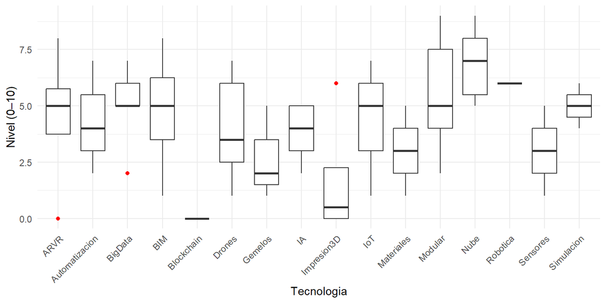

Visualización del nivel de implementación de las tecnologías

En conjunto, los resultados permiten concluir que los valores atípicos identificados no deben eliminarse, puesto que representan información relevante sobre el estado real de adopción tecnológica en SEDEMI. Estos valores constituyen evidencia empírica de que la implementación de tecnologías emergentes avanza de manera desigual y que la empresa enfrenta disparidades internas en capacidades digitales, infraestructura tecnológica y disponibilidad de recursos. La identificación de estas observaciones extremas es por tanto fundamental para los análisis posteriores, puesto que permiten caracterizar de manera más precisa las brechas tecnológicas y orientar futuras estrategias de desarrollo digital.

### 3.1.3 Análisis univariado (estadísticos descriptivos)

El análisis descriptivo del nivel de implementación de tecnologías asociadas a la Construcción 4.0 en SEDEMI que se presenta en el Cuadro 1, revela un panorama heterogéneo en el que convergen tecnologías ampliamente utilizadas con otras que aún se encuentran en fases iniciales de adopción. En primera instancia, se observa que algunas tecnologías presentan niveles relativamente altos de integración. La computación en la nube constituye el caso más evidente, pues alcanza un promedio de 6.86 puntos y muestra una baja dispersión entre las respuestas. Esto sugiere un uso consistente y maduro a nivel organizacional, probablemente porque facilita la colaboración, el acceso a información en tiempo real y la gestión centralizada de datos. De manera similar, la construcción modular o prefabricada registra un promedio de 5.57, lo que indica un grado de incorporación intermedio-alto, posiblemente asociado a la ejecución de proyectos donde esta metodología optimiza tiempos, reduce costos o estandariza procesos.

Estadísticos descriptivos del nivel de implementación de tecnologías 4.0

| Tecnología | N | Media | DE | Var | Med | MAD | Min | Max | Rango | Asim | Curt | EE |
| --- | --- | --- | --- | --- | --- | --- | --- | --- | --- | --- | --- | --- |
| BIM | 8 | 4.75 | 2.38 | 5.64 | 5.0 | 2.22 | 1 | 8 | 7 | -0.24 | -1.45 | 0.84 |
| IA | 5 | 3.80 | 1.30 | 1.70 | 4.0 | 1.48 | 2 | 5 | 3 | -0.26 | -1.96 | 0.58 |
| IoT | 3 | 4.33 | 3.06 | 9.33 | 5.0 | 2.97 | 1 | 7 | 6 | -0.21 | -2.33 | 1.76 |
| Gemelos | 3 | 2.67 | 2.08 | 4.33 | 2.0 | 1.48 | 1 | 5 | 4 | 0.29 | -2.33 | 1.20 |
| BigData | 5 | 5.00 | 1.87 | 3.50 | 5.0 | 1.48 | 2 | 7 | 5 | -0.55 | -1.40 | 0.84 |
| Nube | 7 | 6.86 | 1.57 | 2.48 | 7.0 | 1.48 | 5 | 9 | 4 | -0.02 | -1.86 | 0.59 |
| Simulacion | 2 | 5.00 | 1.41 | 2.00 | 5.0 | 1.48 | 4 | 6 | 2 | 0.00 | -2.75 | 1.00 |
| Robotica | 1 | 6.00 | NA | NA | 6.0 | 0.00 | 6 | 6 | 0 | NA | NA | NA |
| Impresion3D | 4 | 1.75 | 2.87 | 8.25 | 0.5 | 0.74 | 0 | 6 | 6 | 0.69 | -1.73 | 1.44 |
| Drones | 8 | 3.88 | 2.30 | 5.27 | 3.5 | 3.71 | 1 | 7 | 6 | 0.01 | -1.77 | 0.81 |
| Automatizacion | 3 | 4.33 | 2.52 | 6.33 | 4.0 | 2.97 | 2 | 7 | 5 | 0.13 | -2.33 | 1.45 |
| Sensores | 3 | 3.00 | 2.00 | 4.00 | 3.0 | 2.97 | 1 | 5 | 4 | 0.00 | -2.33 | 1.15 |
| Materiales | 3 | 3.00 | 2.00 | 4.00 | 3.0 | 2.97 | 1 | 5 | 4 | 0.00 | -2.33 | 1.15 |
| Blockchain | 1 | 0.00 | NA | NA | 0.0 | 0.00 | 0 | 0 | 0 | NA | NA | NA |
| ARVR | 4 | 4.50 | 3.32 | 11.00 | 5.0 | 2.22 | 0 | 8 | 8 | -0.33 | -1.84 | 1.66 |
| Modular | 7 | 5.57 | 2.51 | 6.29 | 5.0 | 2.97 | 2 | 9 | 7 | 0.04 | -1.73 | 0.95 |

En contraste, otras tecnologías presentan un nivel de adopción moderado o incipiente. BIM, por ejemplo, alcanza un promedio de 4.75, lo que refleja un uso significativo en determinados proyectos, aunque con variaciones notables entre áreas de la empresa. La inteligencia artificial obtiene un promedio de 3.80, lo que evidencia que su integración está en una fase de exploración, enfocada en aplicaciones puntuales más que en una implementación transversal. La simulación digital, con un promedio de 5.00, muestra una adopción moderada vinculada a actividades de planificación o análisis técnico. Tecnologías como drones y automatización presentan valores similares, aunque acompañados de mayor dispersión, lo cual indica que ciertos equipos las utilizan de forma frecuente mientras que otros apenas comienzan a incorporarlas.

En lo referente a la consistencia de las respuestas, las medidas de dispersión, como la desviación estándar, el rango y la varianza, permiten identificar diferencias relevantes entre tecnologías. Aquellas que muestran valores moderados o bajos de variabilidad, como nube, simulación o IA, reflejan percepciones relativamente uniformes entre los participantes. En cambio, tecnologías como impresión 3D, drones y automatización presentan una variabilidad elevada, lo que sugiere que la adopción depende en gran medida del tipo de proyecto, del área operativa o del nivel de familiaridad técnica del equipo. Asimismo, la presencia frecuente de asimetrías negativas indica que, en varios casos, existen usuarios que reportan niveles altos de implementación, lo cual empuja la distribución hacia valores superiores, un comportamiento típico en contextos donde ciertos departamentos avanzan más rápidamente que otros en la adopción de tecnologías innovadoras.

En conjunto, los resultados permiten concluir que SEDEMI presenta un perfil de adopción tecnológica diverso, caracterizado por avances consolidados en tecnologías digitales de soporte, como la nube y BIM, niveles intermedios de incorporación en tecnologías de optimización, como IA, simulación y automatización, y un desarrollo incipiente en tecnologías emergentes, tales como gemelos digitales, impresión 3D, sensores IoT o blockchain. Esta estructura evidencia una madurez tecnológica en proceso de consolidación y constituye un insumo fundamental para el análisis posterior del índice de madurez 4.0, la identificación de brechas internas y el diseño de estrategias orientadas a fortalecer la adopción tecnológica y la transformación digital en los próximos años.

#### 3.1.3.1 Comparación del nivel de implementación por tecnología

La figura 2 que compara el nivel de implementación de tecnologías asociadas a la Construcción 4.0 en SEDEMI permite identificar un comportamiento claramente heterogéneo dentro del ecosistema digital de la empresa. En términos generales, se observa que la organización avanza en un proceso de transformación tecnológica que no ocurre de manera uniforme, sino que presenta diferencias significativas según el tipo de tecnología evaluada. Este patrón, que combina tecnologías ampliamente adoptadas con otras aún en fases iniciales, es coherente con lo que suele ocurrir en empresas del sector construcción, donde la incorporación de herramientas digitales está condicionada por factores técnicos, organizacionales y económicos.

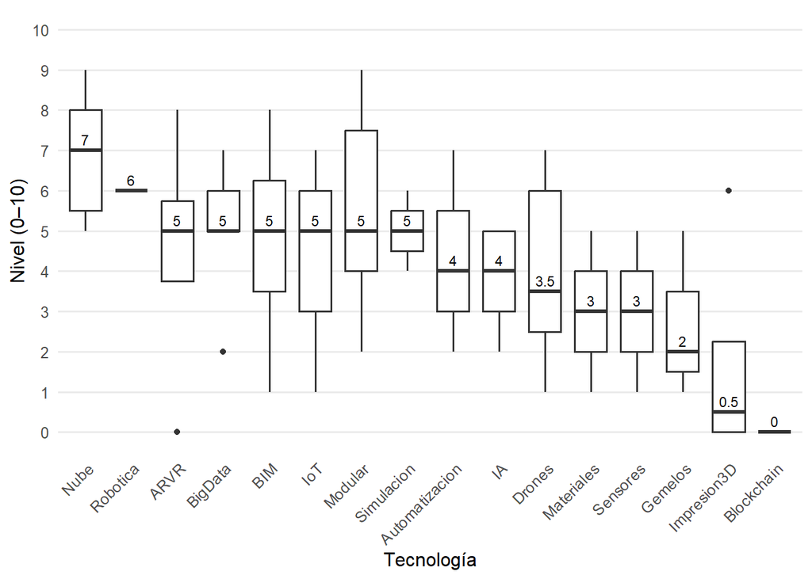

Nivel de implementación por tecnología 4.0

En primer lugar, la computación en la nube se posiciona como la tecnología de mayor nivel de implementación. Su mediana alcanza siete puntos y la baja variabilidad entre las respuestas sugiere que se trata de una herramienta integrada de manera consistente en la mayoría de los procesos organizacionales. Este comportamiento resulta comprensible si se considera que la nube facilita la gestión colaborativa de información, el acceso remoto a datos y la estandarización de flujos de trabajo, lo que la convierte en un eje articulador de la digitalización en SEDEMI. De manera complementaria, la robótica también presenta un valor mediano elevado, aunque su interpretación requiere cautela debido al número reducido de observaciones. Este valor indica que, al menos en ciertos casos, la empresa ha comenzado a incorporar soluciones de automatización avanzada, lo cual representa un indicio de innovación aplicada en procesos específicos.

En contraste con estas tecnologías de alta adopción, existe un grupo amplio conformado por AR y VR, Big Data, BIM, IoT, la construcción modular y la simulación digital, cuya mediana se sitúa alrededor de cinco puntos. La presencia de este conjunto intermedio revela que SEDEMI ha alcanzado un nivel relevante de conocimiento y uso en estas herramientas, aunque aún no logra una integración completamente homogénea en todos sus proyectos o áreas. Además, la dispersión observada en algunas de estas tecnologías sugiere que su adopción depende en parte de la experiencia de los equipos, de las exigencias particulares de cada obra o de la existencia de lineamientos internos que faciliten o limiten su aplicación. En el caso de BIM, por ejemplo, la variabilidad encontrada se corresponde con estudios previos que señalan la influencia de factores como la resistencia al cambio, la falta de procesos estandarizados y la desigual disponibilidad de competencias digitales dentro del personal técnico.

Posteriormente, se identifican tecnologías con niveles de adopción moderados que incluyen inteligencia artificial, drones, materiales avanzados y sensores IoT. Las medianas situadas entre tres y cuatro puntos reflejan que la empresa reconoce el valor potencial de estas herramientas, pero también que su uso todavía no se encuentra consolidado. En particular, los drones presentan una dispersión mayor, lo que indica que algunas áreas los utilizan intensivamente, mientras otras no los han incorporado. Este comportamiento evidencia que SEDEMI se encuentra en una etapa transicional respecto a estas tecnologías, en la que su incorporación depende de manera directa de la disponibilidad de capacidades técnicas, de la percepción de utilidad o de la presencia de procesos que estructuren su uso sistemático.

Finalmente, se observa que tecnologías como los gemelos digitales, la impresión tridimensional y la blockchain presentan los niveles más bajos de adopción, con medianas iguales o inferiores a dos puntos. Estas herramientas se encuentran en una fase claramente exploratoria dentro de SEDEMI, lo que coincide con la situación del sector a nivel internacional. La adopción limitada de estas tecnologías suele responder a las elevadas exigencias técnicas, la necesidad de inversiones sustanciales, la complejidad de integración con sistemas existentes y la escasez de perfiles especializados capaces de operarlas y mantenerlas. En consecuencia, su incorporación requiere estrategias específicas que permitan desarrollar capacidades internas y asegurar su alineación con los objetivos estratégicos de la organización.

Considerando estos resultados de manera conjunta, se puede concluir que SEDEMI presenta una estructura de adopción tecnológica que se asemeja a un modelo progresivo en el que coexisten tecnologías consolidadas, tecnologías en expansión y tecnologías emergentes. Este patrón revela que la empresa se encuentra en una fase intermedia de madurez digital y que, si bien ha logrado avances importantes en herramientas que actúan como habilitadores transversales, todavía enfrenta desafíos relevantes para incorporar tecnologías más avanzadas. Por tanto, los hallazgos del análisis son esenciales para orientar las decisiones estratégicas futuras, ya que permiten identificar brechas prioritarias, definir líneas de acción y establecer una ruta clara hacia la consolidación de un modelo operativo plenamente alineado con los principios de la Construcción 4.0.

#### 3.1.3.2 Índice de madurez tecnológica 4.0

El análisis del índice de madurez tecnológica 4.0, construido a partir del promedio de las dieciséis tecnologías evaluadas, permite obtener una visión sintética del nivel global de digitalización en SEDEMI. Tal como se presenta en la Tabla 4, el índice alcanza un valor medio de 4.87 puntos, acompañado de una mediana de 4.43. Esta convergencia entre ambas medidas indica que la mayoría de los participantes se sitúa alrededor de un nivel intermedio de madurez tecnológica. En consecuencia, se puede afirmar que la empresa ha incorporado ciertas herramientas digitales de manera consistente, aunque aún se encuentra lejos de una adopción plenamente consolidada.

Estadísticos descriptivos del índice de madurez tecnológica 4.0

| N | Media | DE | Var | Med | MAD | Min | Max | Rango | Asim | Curt | EE |
| --- | --- | --- | --- | --- | --- | --- | --- | --- | --- | --- | --- |
| 9 | 4.87 | 2.12 | 4.47 | 4.43 | 1.79 | 1.73 | 9 | 7.27 | 0.42 | -0.75 | 0.71 |

Al examinar las medidas de dispersión reportadas en la tabla, se observa que la desviación estándar asciende a 2.12 puntos y que el rango total alcanza los 7.27 puntos, lo cual evidencia diferencias marcadas entre distintas áreas o grupos dentro de la organización. Esta amplitud sugiere que coexisten equipos con niveles altos de digitalización junto a otros que mantienen una adopción incipiente. Esta heterogeneidad es una característica frecuente en empresas de ingeniería y construcción, donde la incorporación tecnológica avanza de forma desigual debido a la diversidad de proyectos, funciones operativas y capacidades internas.

Por otra parte, la curtosis negativa (-0.75) señala que la distribución presenta una forma más aplanada de lo esperado, lo que implica una mayor dispersión y la ausencia de un punto dominante de concentración. En otras palabras, la madurez tecnológica en SEDEMI no se agrupa alrededor de un único valor predominante, sino que se distribuye ampliamente entre niveles bajos, medios y altos. Este comportamiento refuerza la idea de que la empresa avanza en un proceso de transformación digital en desarrollo, caracterizado por diferencias internas que deben ser abordadas estratégicamente.

### 3.1.4 Análisis multivariante exploratorio (correlaciones)

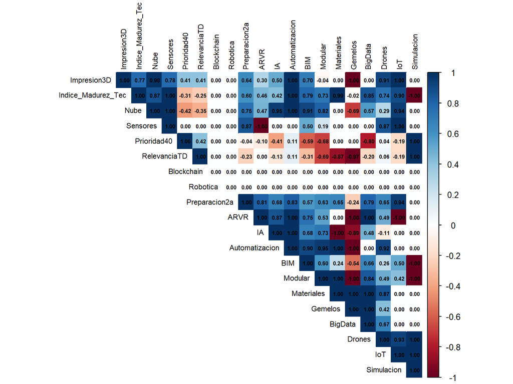

Matriz de correlaciones entre Tecnologías 4.0 y variables organizacionales

Finalmente, algunos patrones de correlación negativa sugieren la existencia de brechas internas en el uso tecnológico. En ciertos casos, tecnologías asociadas a procesos tradicionales o analíticos muestran relaciones inversas con herramientas más disruptivas. Aunque estas asociaciones deben interpretarse con prudencia debido al tamaño muestral, aportan indicios preliminares sobre diferencias entre áreas operativas o niveles de especialización dentro de la empresa.

En conjunto, los resultados del análisis de correlaciones indican que SEDEMI presenta un ecosistema digital estructurado en tres grupos principales. El primero corresponde a tecnologías consolidadas que avanzan de manera conjunta y que constituyen la base de la digitalización organizacional. El segundo incluye tecnologías en expansión con vínculos parciales hacia el núcleo digital. El tercero está conformado por tecnologías emergentes cuya adopción aún no se articula con los procesos internos. Esta caracterización proporciona un marco interpretativo sólido para orientar decisiones estratégicas, planificar inversiones y fortalecer las capacidades digitales de la organización.

### 3.1.5 Aplicación del proceso KDD (Knowledge Discovery)

La aplicación del proceso KDD (Knowledge Discovery in Databases) en el análisis de Tecnologías 4.0 en SEDEMI permitió estructurar el trabajo analítico siguiendo una secuencia metodológica robusta y ampliamente aceptada en estudios de analítica de datos. Este enfoque resulta especialmente pertinente en investigaciones que integran múltiples fuentes y tipos de información, como es el caso de la evaluación de capacidades tecnológicas en organizaciones del sector construcción. En la Tabla 5 se sintetizan las fases del proceso y su aplicación específica dentro del estudio.

Resumen de la aplicación del proceso KDD en el análisis de Tecnologías 4.0 en SEDEMI

| Fase | Descripción | Aplicación en SEDEMI |
| --- | --- | --- |
| Selección de datos | Definición de las fuentes y variables relevantes para el análisis. | Selección de encuestas de diagnóstico, madurez y barreras; identificación de variables de Tecnologías 4.0. |
| Preprocesamiento | Depuración inicial, manejo de valores faltantes y revisión de calidad. | Renombrado de ítems, detección de valores faltantes y atípicos, estandarización de escalas. |
| Transformación | Construcción de nuevas variables o indicadores a partir de los datos. | Cálculo del índice de madurez tecnológica y reestructuración de datos en formato largo. |
| Minería de datos | Aplicación de técnicas estadísticas y exploratorias para descubrir patrones. | Estadísticos descriptivos, boxplots, visualización de outliers y matriz de correlaciones. |
| Interpretación | Análisis sustantivo de resultados y extracción de conclusiones. | Identificación de tecnologías consolidadas, en expansión y emergentes; análisis estratégico. |

En primer lugar, la fase de selección de datos consistió en identificar las fuentes de información relevantes para la investigación, lo que implicó elegir tres instrumentos clave: la encuesta de diagnóstico tecnológico, la encuesta de madurez organizacional y la encuesta de barreras y fuerzas para la adopción digital. Esta etapa permitió establecer un marco de datos coherente y alineado con los objetivos analíticos del estudio.

Posteriormente, en la fase de preprocesamiento, se llevó a cabo la depuración inicial de la base de datos. Esto incluyó el tratamiento de valores faltantes, la detección de valores atípicos y la estandarización de escalas, así como el renombramiento y estructuración de ítems para facilitar su posterior análisis. Este proceso fue fundamental para garantizar la calidad y consistencia interna de los datos utilizados.

A continuación, la fase de transformación permitió generar nuevas variables e indicadores derivados, entre los cuales destaca la construcción del índice de madurez tecnológica 4.0, elaborado a partir del promedio de los niveles de implementación de dieciséis tecnologías evaluadas. Asimismo, se reorganizó la base de datos en formato largo con el fin de facilitar la representación gráfica y el análisis comparativo entre tecnologías.

La fase de minería de datos, por su parte, consistió en la aplicación de técnicas estadísticas descriptivas y exploratorias orientadas a identificar patrones relevantes en los datos. Entre estas técnicas se incluyeron el cálculo de estadísticos de tendencia central y dispersión, la visualización de valores atípicos mediante diagramas de caja, y la elaboración de una matriz de correlaciones que permitió examinar relaciones entre tecnologías, niveles de madurez y variables organizacionales.

Finalmente, la fase de interpretación integró los hallazgos obtenidos en las fases anteriores, permitiendo identificar tecnologías consolidadas, tecnologías en expansión y tecnologías emergentes dentro de SEDEMI. Esta etapa facilitó la extracción de conclusiones estratégicas orientadas a reconocer brechas internas, evaluar el grado de avance hacia la Construcción 4.0 y generar insumos para la formulación de recomendaciones en torno al desarrollo digital de la organización.

En conjunto, la aplicación del proceso KDD otorgó coherencia metodológica al estudio y permitió transformar los datos recogidos en conocimiento útil para la toma de decisiones. Además, garantizó que cada etapa del análisis estuviera sustentada en procedimientos sistemáticos que fortalecen la validez y robustez de los resultados obtenidos.

### 3.1.6 Interpretación de patrones

Los resultados presentados en la Tabla 6 permiten identificar patrones globales y locales en el comportamiento de adopción de Tecnologías 4.0 en SEDEMI. En términos generales, se observa que la empresa presenta un ecosistema digital heterogéneo, caracterizado por tecnologías con niveles de adopción consolidados, otras en fases intermedias de implementación y un conjunto que permanece en etapa incipiente. Este tipo de estructura escalonada es consistente con estudios previos sobre madurez digital en el sector de la construcción, donde la adopción ocurre de manera gradual y diferenciada entre áreas, procesos y equipos.

#### 3.1.6.1 Resumen de niveles de adopción y categorías

En primer lugar, se identifican tecnologías de alta adopción, entre las cuales destacan la computación en la nube (media = 6.86) y la robótica (media = 6.00). Estas tecnologías conforman un patrón global asociado a herramientas transversales, cuyo uso facilita la coordinación operativa, la gestión de datos y la automatización de tareas repetitivas. Su posición en la categoría “Alta adopción” refleja que SEDEMI ha avanzado significativamente en la incorporación de soluciones que mejoran la eficiencia y la visibilidad del proyecto en distintos niveles de la organización.

Resumen de niveles de adopción y categorías de tecnologías 4.0

| Tecnologia | Media | DE | Categoria de adopcion |
| --- | --- | --- | --- |
| Nube | 6.86 | 1.57 | Alta adopción |
| Robotica | 6.00 | NA | Alta adopción |
| Modular | 5.57 | 2.51 | Adopción intermedia |
| BigData | 5.00 | 1.87 | Adopción intermedia |
| Simulacion | 5.00 | 1.41 | Adopción intermedia |
| BIM | 4.75 | 2.38 | Adopción intermedia |
| ARVR | 4.50 | 3.32 | Adopción intermedia |
| IoT | 4.33 | 3.06 | Adopción intermedia |
| Automatizacion | 4.33 | 2.52 | Adopción intermedia |
| Drones | 3.88 | 2.30 | Adopción intermedia |
| IA | 3.80 | 1.30 | Adopción intermedia |
| Sensores | 3.00 | 2.00 | Adopción intermedia |
| Materiales | 3.00 | 2.00 | Adopción intermedia |
| Gemelos | 2.67 | 2.08 | Adopción incipiente |
| Impresion3D | 1.75 | 2.87 | Adopción incipiente |
| Blockchain | 0.00 | NA | Adopción incipiente |

Luego, se observa un conjunto amplio de tecnologías clasificadas como adopción intermedia, entre las que se incluyen la construcción modular, Big Data, simulación digital, BIM, AR/VR, automatización, Internet de las Cosas (IoT), drones, inteligencia artificial y materiales avanzados. Este grupo constituye un patrón intermedio, donde las herramientas han logrado cierto grado de integración, pero presentan variabilidad entre áreas y proyectos. La dispersión observada en algunas de estas tecnologías—como AR/VR, automatización o drones—indica que su uso todavía depende de factores como la disponibilidad de capacidades técnicas, la familiaridad del personal o la existencia de proyectos que demanden su aplicación directa. Este comportamiento coincide con la literatura que señala que las tecnologías de optimización suelen avanzar a ritmos desiguales, especialmente cuando requieren inversiones en capacitación o infraestructura.

Finalmente, un grupo menor incluye tecnologías con adopción incipiente, tales como los gemelos digitales, la impresión 3D y blockchain. Estas tecnologías presentan medias bajas y altos niveles de dispersión, lo que sugiere una adopción limitada, experimental o concentrada en áreas muy específicas. En particular, blockchain muestra un promedio igual a cero, lo cual indica que su uso aún no ha sido explorado en la organización. Este patrón local revela la existencia de brechas tecnológicas en áreas emergentes que, si bien poseen un alto potencial estratégico, requieren esfuerzos adicionales de inversión, formación técnica y alineación organizacional para consolidarse.

#### 3.1.6.2 Pares de tecnologías 4.0 con correlaciones fuertes

La Tabla 7 complementa este análisis al identificar pares de tecnologías con correlaciones fuertes (|r| >= 0.70), lo que permite reconocer agrupamientos o clústeres de adopción dentro de SEDEMI. Estos resultados evidencian que existen tecnologías que tienden a implementarse de manera conjunta, posiblemente debido a que su uso responde a capacidades compartidas, necesidades similares o procesos integrados.

Pares de tecnologías 4.0 con correlaciones fuertes (|r| >= 0.70)

| Tec1 | Tec2 | cor |
| --- | --- | --- |
| IoT | Simulacion | 1.00 |
| IoT | Sensores | 1.00 |
| Gemelos | Materiales | 1.00 |
| BigData | Gemelos | 1.00 |
| BigData | Materiales | 1.00 |
| Nube | Sensores | 1.00 |
| Impresion3D | IoT | 1.00 |
| Drones | Simulacion | 1.00 |
| Automatizacion | IA | 1.00 |
| Automatizacion | Nube | 1.00 |
| Automatizacion | Impresion3D | 1.00 |
| Automatizacion | Materiales | 1.00 |
| Materiales | Modular | 1.00 |
| ARVR | BigData | 1.00 |
| ARVR | Automatizacion | 1.00 |
| Impresion3D | Nube | 0.98 |
| Automatizacion | Modular | 0.95 |
| IA | Nube | 0.95 |
| IoT | Nube | 0.94 |
| Drones | IoT | 0.93 |
| Automatizacion | Drones | 0.92 |
| Drones | Impresion3D | 0.91 |
| BIM | Nube | 0.91 |
| Automatizacion | BIM | 0.90 |
| Drones | Sensores | 0.87 |
| Drones | Materiales | 0.87 |
| ARVR | IA | 0.87 |
| BigData | Modular | 0.84 |
| Modular | Nube | 0.82 |
| Impresion3D | Sensores | 0.78 |
| ARVR | BIM | 0.75 |
| IA | Modular | 0.73 |
| Gemelos | IA | -0.89 |
| BIM | Simulacion | -1.00 |
| IA | Materiales | -1.00 |
| Gemelos | Impresion3D | -1.00 |
| Gemelos | Modular | -1.00 |
| Automatizacion | Gemelos | -1.00 |
| ARVR | IoT | -1.00 |
| ARVR | Gemelos | -1.00 |
| ARVR | Sensores | -1.00 |
| Modular | Simulacion | -1.00 |

Por ejemplo, se observan correlaciones altas entre IoT, simulación y sensores, lo que indica que estas tecnologías suelen aplicarse en proyectos orientados a la monitorización y análisis en tiempo real. Del mismo modo, se encuentra un clúster relevante entre Big Data, materiales avanzados y gemelos digitales, lo que sugiere que la explotación de datos y el modelado virtual están asociados a procesos de innovación y análisis sofisticado de desempeño. Otro grupo significativo incluye a automatización, impresión 3D y tecnologías modulares, que representan un conjunto de herramientas vinculadas a la industrialización de la construcción y a la optimización de procesos productivos. Finalmente, se observan correlaciones altas entre computación en la nube, BIM y automatización, lo cual coincide con investigaciones que destacan que la gestión de datos en la nube potencia la interoperabilidad con modelos BIM y facilita la automatización de flujos de trabajo digitales.

En conjunto, el análisis de correlaciones revela que la adopción tecnológica en SEDEMI no se desarrolla de manera aislada, sino que configura redes de tecnologías complementarias, donde la incorporación de una herramienta favorece la implementación de otras relacionadas. Esta estructura relacional coincide con el enfoque de “clusters de digitalización” documentado en la literatura internacional, según el cual las organizaciones avanzan en su madurez digital mediante la integración progresiva de paquetes tecnológicos y no de herramientas individuales.

En síntesis, la identificación de patrones globales y locales, junto con la detección de clústeres de adopción, proporciona una visión integral del estado tecnológico de SEDEMI. Mientras que algunas tecnologías se encuentran sólidamente implementadas, otras avanzan hacia una consolidación gradual y un grupo importante permanece en etapa inicial. Este diagnóstico constituye una base sólida para orientar decisiones estratégicas orientadas a fortalecer las capacidades digitales de la empresa y avanzar hacia un modelo operativo plenamente alineado con la Construcción 4.0.

## 3.2 Identificación de valores mínimos y máximos,conteos (QUERY)

### 3.2.1 Identificación de valores mínimos y máximos por tecnología

La Tabla 8 presenta los valores mínimos y máximos registrados en el nivel de implementación de cada tecnología 4.0 dentro de SEDEMI, junto con la identificación de los participantes que reportaron dichos valores extremos. Este análisis permite comprender no solo el rango de variación de cada tecnología, sino también qué personas o unidades de la organización se ubican en los extremos de adopción, lo cual es fundamental para identificar brechas internas.

Valores mínimos y máximos de implementación por tecnología 4.0

| Tecnologia | Nivel_min | Participante_min | Nivel_max | Participante_max |
| --- | --- | --- | --- | --- |
| BIM | 1 | 2 | 8 | 6 |
| IA | 2 | 4 | 5 | 5, 8 |
| IoT | 1 | 1 | 7 | 5 |
| Gemelos | 1 | 5 | 5 | 4 |
| BigData | 2 | 2 | 7 | 3 |
| Nube | 5 | 2, 4 | 9 | 7 |
| Simulacion | 4 | 6 | 6 | 5 |
| Robotica | 6 | 5 | 6 | 5 |
| Impresion3D | 0 | 2, 8 | 6 | 5 |
| Drones | 1 | 2, 9 | 7 | 4 |
| Automatizacion | 2 | 2 | 7 | 5 |
| Sensores | 1 | 1 | 5 | 5 |
| Materiales | 1 | 2 | 5 | 4 |
| Blockchain | 0 | 1 | 0 | 1 |
| ARVR | 0 | 2 | 8 | 1 |
| Modular | 2 | 2 | 9 | 8 |

Por otra parte, la misma tabla evidencia que tecnologías como gemelos digitales, sensores IoT, materiales avanzados, impresión 3D, AR/VR y especialmente blockchain presentan valores mínimos muy bajos, e incluso igual a 0. Este valor representa la ausencia total de implementación para ciertos participantes, lo que es habitual en tecnologías emergentes que aún no están plenamente integradas dentro del sector construcción. Este patrón revela que la familiaridad y el uso de estas herramientas no es homogéneo, sino que depende del área de trabajo, de la función desempeñada y del grado de exposición previa a soluciones tecnológicas avanzadas.

Además, la presencia de múltiples participantes con valores mínimos en una misma tecnología refleja brechas internas claras, donde algunos equipos no han adoptado herramientas que sí están siendo utilizadas por otros grupos. Este fenómeno coincide con lo observado en empresas que se encuentran en transición hacia la digitalización, donde el nivel de adopción suele avanzar de manera gradual y desigual.

En conjunto, la Tabla 8 muestra que SEDEMI presenta una estructura de adopción tecnológica heterogénea, con tecnologías consolidadas en ciertos departamentos y otras aún en fase inicial. Esta información es clave para diseñar estrategias internas de capacitación, priorización de inversiones y fortalecimiento de capacidades digitales.

### 3.2.2 Participantes con nivel 0 por tecnología

La Tabla 9 profundiza en uno de los aspectos más críticos identificados: los casos en los que los participantes reportaron un nivel de implementación igual a cero, es decir, una ausencia total de uso de determinadas tecnologías. Este análisis permite identificar qué personas no han incorporado ciertas herramientas y en qué tecnologías ocurre esta situación.

Participantes con nivel 0 de implementación por tecnología 4.0

| Participante | Tecnologia | Nivel |
| --- | --- | --- |
| 1 | Blockchain | 0 |
| 2 | Impresion3D | 0 |
| 2 | ARVR | 0 |
| 8 | Impresion3D | 0 |

Los resultados muestran que solo cuatro casos registran valores de cero, concentrados en tres tecnologías: blockchain, impresión 3D y AR/VR. La presencia de blockchain con nivel 0 confirma que esta tecnología aún no ha sido explorada dentro de SEDEMI, lo cual es comprensible si se considera que su adopción en la industria de la construcción es todavía limitada a nivel global. Por su parte, la impresión 3D también aparece con valores nulos en más de un participante, lo que indica que su uso es incipiente o experimental dentro de la organización. De manera similar, un participante reporta no utilizar tecnologías de realidad aumentada o virtual, lo que evidencia que su implementación aún no es transversal.

La identificación explícita de los participantes asociados a estos valores permite reconocer qué áreas específicas carecen de exposición o experiencia en tecnologías emergentes. Esta información es valiosa para orientar procesos de capacitación segmentada, definir prioridades de incorporación tecnológica y planificar proyectos piloto que permitan ampliar el uso de estas herramientas.

En conjunto, la Tabla 9 confirma que las tecnologías emergentes presentan las mayores brechas internas de adopción, mientras que las tecnologías más consolidadas presentan valores mínimos más altos y mayor consistencia entre participantes. Este contraste refleja un proceso de digitalización en desarrollo, donde conviven tecnologías plenamente integradas con herramientas innovadoras aún en etapa de exploración.

### 3.2.3 Conteo de participantes con nivel alto (>= 7) en computacion en la nube

La tabla 10 muestra el número de participantes que reportaron un nivel de implementación mayor o igual a 7 en computación en la nube. Este umbral se considera un indicador de alta adopción, dado que se ubica en el tramo superior de la escala utilizada para evaluar el uso de tecnologías 4.0.

Conteo de participantes con nivel alto (>= 7) en computacion en la nube

| Condicion | Participantes |
| --- | --- |
| Nivel de computacion en la nube >= 7 | 4 |

En términos prácticos, el resultado indica que cuatro participantes alcanzan niveles altos de utilización de la computación en la nube dentro de SEDEMI. Este hallazgo es relevante porque evidencia que existe un grupo de colaboradores o áreas que han logrado integrar esta tecnología de manera sólida en sus procesos, lo cual coincide con su rol como herramienta transversal para la gestión de información, la colaboración remota y la digitalización operativa.

Asimismo, este patrón sugiere que la computación en la nube constituye una de las tecnologías más consolidadas en la organización, lo que puede estar asociado a su accesibilidad, madurez del mercado y compatibilidad con múltiples procesos internos. No obstante, el hecho de que solo cuatro participantes superen el umbral de adopción avanzada también indica que existen brechas internas, donde parte del personal aún mantiene niveles medios o bajos de implementación.

En conjunto, la tabla permite identificar un primer indicador positivo de digitalización dentro de SEDEMI, mostrando que la computación en la nube ya cuenta con un núcleo de usuarios avanzados, aunque su adopción plena todavía requiere fortalecerse de manera más amplia en toda la organización.

# 4 Conclusiones

Los resultados del diagnóstico evidencian que SEDEMI se encuentra en una fase intermedia de adopción de Tecnologías 4.0, en la que ya se observan avances relevantes en herramientas habilitadoras, pero todavía persisten brechas importantes para consolidar una transformación digital integral. En este sentido, el análisis exploratorio y descriptivo muestra que la digitalización no progresa de manera uniforme dentro de la organización, sino que se configura como un proceso gradual y diferenciado según el tipo de tecnología, el área y el contexto operativo de los proyectos.

En primer lugar, se identifican tecnologías con niveles de implementación relativamente altos y uso más consistente, destacando la computación en la nube como la herramienta mejor posicionada dentro del ecosistema digital de SEDEMI. Asimismo, tecnologías como BIM, simulación digital, construcción modular, IoT, automatización y drones presentan niveles de adopción intermedios que reflejan una incorporación significativa, aunque todavía no completamente estandarizada. Por consiguiente, estos hallazgos sugieren que la empresa ha construido una base tecnológica funcional que facilita la gestión de información, la colaboración y ciertas mejoras en eficiencia operativa; sin embargo, la variabilidad observada indica que su uso aún depende en gran medida de prácticas y capacidades específicas de determinados equipos.

En contraste, tecnologías emergentes como gemelos digitales, impresión 3D, sensores avanzados, materiales avanzados y blockchain presentan niveles bajos de implementación y, en algunos casos, registros mínimos cercanos a cero. En consecuencia, se puede afirmar que estas herramientas permanecen en una etapa exploratoria o experimental dentro de la organización, lo cual es coherente con su mayor complejidad de integración, los requerimientos de especialización técnica y las inversiones necesarias para su despliegue. De este modo, el diagnóstico confirma que la transformación digital en SEDEMI avanza principalmente en tecnologías de soporte y optimización, mientras que las tecnologías más disruptivas aún no forman parte de los procesos centrales.

Por otra parte, el índice de madurez tecnológica 4.0, construido a partir del promedio de dieciséis tecnologías, sintetiza de manera clara este escenario. Aunque su valor central se ubica en un nivel moderado, la dispersión registrada evidencia una heterogeneidad interna marcada, donde coexisten grupos con madurez digital elevada y otros con adopción incipiente. En consecuencia, SEDEMI no presenta un único nivel de madurez, sino un perfil mixto que revela la necesidad de intervenciones diferenciadas, orientadas a reducir brechas, fortalecer competencias y ampliar la adopción más allá de núcleos específicos de usuarios avanzados.

Adicionalmente, el análisis multivariante exploratorio sugiere que la adopción tecnológica tiende a organizarse en conjuntos o clústeres de implementación, en los que ciertas tecnologías se integran de forma complementaria. Por ello, más que impulsar tecnologías de manera aislada, resulta estratégico consolidar paquetes tecnológicos coherentes (por ejemplo, gestión de datos, interoperabilidad y automatización de flujos), ya que esta lógica favorece una evolución más estable de la madurez digital. En este marco, la evidencia obtenida respalda la idea de que la consolidación de tecnologías habilitadoras puede actuar como plataforma para integrar herramientas más avanzadas en etapas posteriores.

Finalmente, desde una perspectiva aplicada, los hallazgos proporcionan insumos directos para la gestión estratégica de la transformación digital en SEDEMI. En particular, se recomienda priorizar la estandarización de tecnologías ya maduras, fortalecer programas de capacitación segmentada para reducir brechas internas y desarrollar proyectos piloto con tecnologías emergentes que permitan evaluar su viabilidad y valor agregado en contextos reales. De este modo, el estudio no solo describe el estado actual de adopción tecnológica, sino que también orienta una ruta progresiva para avanzar hacia un modelo operativo alineado con los principios de la Construcción 4.0.

# Referencias

Alaloul, W., Liew, M. H., Zawawi, N., & Kennedy, M. (2020). Digital construction: From BIM to digital twins. *Journal of Information Technology in Construction*, *25*, 58-78.

Barbosa, F., Woetzel, J., Mischke, J., Ribeirinho, M. J., Sridhar, M., Parsons, M., & Bertram, N. (2017). Reinventing construction: A route to higher productivity. *McKinsey Global Institute*.

Betancourt, J., Mart??nez, L., & Quintero, D. (2021). Digital transformation in Latin American construction: challenges and opportunities. *Journal of Construction Engineering and Management*, *147*(6).

Carrillo, P., & Patel, M. (2021). Digitalization strategies in construction companies: A maturity-based approach. *Journal of Construction Engineering and Management*, *147*(12), 04021175.

Construction Industry Council. (2018). *Smart Construction: Digital Transformation Framework*. CIC.

Delgado, J., & Aranda-Mena, G. (2023). A framework for assessing digital transformation in construction organizations. *Automation in Construction*, *148*, 104783.

Moum, A., & Svidt, K. (2021). Construction 4.0 and the adoption of emerging technologies: A maturity perspective. *Automation in Construction*, *129*, 103847.

Oesterreich, T. C., & Teuteberg, F. (2016). Understanding the implications of digitisation and automation in the construction industry: A systematic literature review. *Automation in Construction*, *70*, 69-86.

Park, J., Montero, C., & Kim, J. (2020). Data-driven methods for understanding digital construction processes. *Advanced Engineering Informatics*, *45*, 101117.

P??rez, S., & Torres, J. (2022). Measuring digital maturity in construction organizations using composite indicators. *Journal of Management in Engineering*, *38*(4), 04022050.

Sacks, R., Eastman, C., Lee, G., & Teicholz, P. (2020). *BIM Handbook: A Guide to Building Information Modeling for Owners, Designers, Engineers, Contractors, and Facility Managers* (4.ª ed.). Wiley.

Succar, B. (2010). The Australian BIM Maturity Model. *Journal of Building*, *1*(1), 1-28.